# PHASE 3

# DATA MINING PHASE 3

## Main Goal :

### nowdays laptops are important because they offer portability, convenience, and functionality. since they allow us to work, study, connect with other people it become an essential tools for us to do our work and study, and the most important factor to choose a laptop is the price so our role in this project is predict prices from different companies depending on several feature such as type name, CPU, GPU, screen resolution and more. we chose this dataset because we think it will help us build a classification and clustering model that will help others choose the appropriate laptop that satisfies their prefrences and budget.

## Dataset source :

### https://www.kaggle.com/datasets/muhammetvarl/laptop-price

## Number of objects :

### 1303

## Number of attribute :

### 13

## dataset summary :

##### The dataset includes :

##### 1- Laptop ID : Numeric - a unique number identifies laptops - has values from 1 to 1303.

##### 2- Company : String - laptop manufacture - include companies like dell, HP, lenovo, and asos … etc.

##### 3- Product : String - brand and model for each company.

##### 4- TypeName : String - type of the laptop ( notebook,ultrabook,gaming…etc).

##### 5- Inches : Numeric - screen size - ranges between 10.1 to 18.4

##### 6- ScreenResulotion : Numeric - screen resulotion - ranges between 1366x768 and 3840x2160.

##### 7- CPU : String - central processing unit - Intel core i3, intel core i5, intel i5 and more.

##### 8- Ram : numeric - laptop ram - 8GB, 16GB, 4GB, 2GB, 12GB, 6GB, 32GB, 24GB, and 64GB.

##### 9- Memory : String - hard disk / SSD memory - HDD, SSD, flash storage and hybrid.

##### 10- Gpu : String - graphics processing unit - AMD, Nvidia, and Intel.

##### 11- OpSys : String - operating system -macOS, No OS, Windows 10, Mac OS X, Linux, Android, Windows 10 S, Chrome OS, and Windows.

##### 12- Weight : numeric - laptop weight - ranges between 0.81Kg to 4.7Kg.

##### 13- Price_euros : Numeric - price in euro - ranges between 174 to 6099 euros.

## class lables :

##### inexpensive

##### ideal price

##### moderetly expensive

##### expinsive

##### very expensive

##### importing needed packages

### 10: classification

##### read the new dataset after preproccessing and cleaning

```r
library(readr)
new_dataset <- read.csv("./new_dataset.csv", header = TRUE , sep = ',' , stringsAsFactors = T)
```

##### importing needed packages

```r
install.packages('party')
```

[output not shown]

```r
library(party)
install.packages('caret')
```

[output not shown]

```r
library(caret)
install.packages("rpart")
```

[output not shown]

```r
library(rpart)
install.packages("rpart.plot")
```

[output not shown]

```r
library(rpart.plot)
```

#### We split the dataset into training data, and testing data using random sampling. We splited our data 70-30%, 60-40%, and 80-20%.

#### 70% training 30% testing

##### first we set the seed and then split the dataset into 70% training 30% testing and lastly define the formula

```r
set.seed(1234)
ind <- sample(2, nrow(new_dataset), replace=TRUE, prob=c(0.7, 0.3))
trainData <- new_dataset[ind==1,]
testData <- new_dataset[ind==2,]

myFormula <- price ~    Company + TypeName + Inches + ScreenResolution + Ram + OpSys + Weight + CPU + GPU + MemoryType + MemorySize
```

#### Information gain

##### we used ctree as decision tree function

```r
new_dataset_ctree <- ctree(myFormula, data=trainData)
```

##### 154 of inexpensive were classified correctly, 32 were classified as ideal price, 2 as moderetly expensive.

##### 152 of moderetly expensive were classified correctly, 66 were classified as expensive, 94 were classified as ideal price and 18 as very expensive.

##### 58 of very expensive were classified correctly, 16 were classified as expensive, 4 were classified as ideal price and 15 as moderetly expensive.

##### as we can see the result is not accurate since our dataset is imbalanced.

[figure not shown]

```r
# check the prediction
plot(new_dataset_ctree,type="simple") #unreadable tree
```

```r
table(predict(new_dataset_ctree), trainData$price)
```

```
                      expinsive ideal price inexpensive moderetly expensive very expensive
  expinsive                  27           0           0                  18             18
  ideal price                 0         199          24                  23              2
  inexpensive                 0          32         154                   2              0
  moderetly expensive        66          94           0                 152             18
  very expensive             16           4           0                  15             58
```

##### 9 of expensive were classified correctly and 12 were classified as moderetly expensive and 11 as very expensive.

##### 70 of ideal price were classified correctly, 12 were classified as inexpensive, 15 were classified as moderetly expensive and 1 as very expensive.

##### 55 of inexpensive were classified correctly and 11 as ideal price.

##### 73 of moderetly expensive were classified correctly, 33 were classified as expensive, 25 were classified as ideal price, 1 were classified as inexpensive and 10 as very expensive.

##### 19 of very expensive were classified correctly, 16 were classified as expensive, 2 were classified as ideal price and 6 as moderetly expensive.

##### we conclude from these results that information gain is not the most appropriate method to classify our dataset.

```r
# predict on test data
testPred <- predict(new_dataset_ctree, newdata = testData)
table(testPred, testData$price)
```

```
testPred              expinsive ideal price inexpensive moderetly expensive very expensive
  expinsive                   9           0           0                  12             11
  ideal price                 0          70          12                  15              1
  inexpensive                 0          11          55                   0              0
  moderetly expensive        33          25           1                  73             10
  very expensive             16           2           0                   6             19
```

##### calculating the overall accuracy

```r
#Accuracy of model
results <- confusionMatrix(testPred, testData$price)
acc <- results$overall["Accuracy"]*100
acc
```

```
Accuracy
59.31759
```

```r
results
```

```
Confusion Matrix and Statistics

                     Reference
Prediction            expinsive ideal price inexpensive moderetly expensive very expensive
  expinsive                   9           0           0                  12             11
  ideal price                 0          70          12                  15              1
  inexpensive                 0          11          55                   0              0
  moderetly expensive        33          25           1                  73             10
  very expensive             16           2           0                   6             19

Overall Statistics

               Accuracy : 0.5932
                 95% CI : (0.542, 0.6429)
    No Information Rate : 0.2835
    P-Value [Acc > NIR] : < 2.2e-16

                  Kappa : 0.47

 Mcnemar's Test P-Value : NA

Statistics by Class:

                     Class: expinsive Class: ideal price Class: inexpensive Class: moderetly expensive
Sensitivity                   0.15517             0.6481             0.8088                     0.6887
Specificity                   0.92879             0.8974             0.9649                     0.7491
Pos Pred Value                0.28125             0.7143             0.8333                     0.5141
Neg Pred Value                0.85960             0.8657             0.9587                     0.8619
Prevalence                    0.15223             0.2835             0.1785                     0.2782
Detection Rate                0.02362             0.1837             0.1444                     0.1916
Detection Prevalence          0.08399             0.2572             0.1732                     0.3727
Balanced Accuracy             0.54198             0.7728             0.8868                     0.7189
                     Class: very expensive
Sensitivity                        0.46341
Specificity                        0.92941
Pos Pred Value                     0.44186
Neg Pred Value                     0.93491
Prevalence                         0.10761
Detection Rate                     0.04987
Detection Prevalence               0.11286
Balanced Accuracy                  0.69641
```

```r
as.table(results)
```

```
                     Reference
Prediction            expinsive ideal price inexpensive moderetly expensive very expensive
  expinsive                   9           0           0                  12             11
  ideal price                 0          70          12                  15              1
  inexpensive                 0          11          55                   0              0
  moderetly expensive        33          25           1                  73             10
  very expensive             16           2           0                   6             19
```

```r
as.matrix(results)
```

```
                    expinsive ideal price inexpensive moderetly expensive very expensive
expinsive                   9           0           0                  12             11
ideal price                 0          70          12                  15              1
inexpensive                 0          11          55                   0              0
moderetly expensive        33          25           1                  73             10
very expensive             16           2           0                   6             19
```

```r
as.matrix(results, what = "overall")
```

```
                       [,1]
Accuracy       5.931759e-01
Kappa          4.699689e-01
AccuracyLower  5.419706e-01
AccuracyUpper  6.429218e-01
AccuracyNull   2.834646e-01
AccuracyPValue 2.421202e-36
McnemarPValue           NaN
```

```r
as.matrix(results, what = "classes")
```

```
                      expinsive ideal price inexpensive moderetly expensive very expensive
Sensitivity          0.15517241   0.6481481   0.8088235           0.6886792     0.46341463
Specificity          0.92879257   0.8974359   0.9648562           0.7490909     0.92941176
Pos Pred Value       0.28125000   0.7142857   0.8333333           0.5140845     0.44186047
Neg Pred Value       0.85959885   0.8657244   0.9587302           0.8619247     0.93491124
Precision            0.28125000   0.7142857   0.8333333           0.5140845     0.44186047
Recall               0.15517241   0.6481481   0.8088235           0.6886792     0.46341463
F1                   0.20000000   0.6796117   0.8208955           0.5887097     0.45238095
Prevalence           0.15223097   0.2834646   0.1784777           0.2782152     0.10761155
Detection Rate       0.02362205   0.1837270   0.1443570           0.1916010     0.04986877
Detection Prevalence 0.08398950   0.2572178   0.1732283           0.3727034     0.11286089
Balanced Accuracy    0.54198249   0.7727920   0.8868399           0.7188851     0.69641320
```

```r
print(results)
```

```
Confusion Matrix and Statistics

                     Reference
Prediction            expinsive ideal price inexpensive moderetly expensive very expensive
  expinsive                   9           0           0                  12             11
  ideal price                 0          70          12                  15              1
  inexpensive                 0          11          55                   0              0
  moderetly expensive        33          25           1                  73             10
  very expensive             16           2           0                   6             19

Overall Statistics

               Accuracy : 0.5932
                 95% CI : (0.542, 0.6429)
    No Information Rate : 0.2835
    P-Value [Acc > NIR] : < 2.2e-16

                  Kappa : 0.47

 Mcnemar's Test P-Value : NA

Statistics by Class:

                     Class: expinsive Class: ideal price Class: inexpensive Class: moderetly expensive
Sensitivity                   0.15517             0.6481             0.8088                     0.6887
Specificity                   0.92879             0.8974             0.9649                     0.7491
Pos Pred Value                0.28125             0.7143             0.8333                     0.5141
Neg Pred Value                0.85960             0.8657             0.9587                     0.8619
Prevalence                    0.15223             0.2835             0.1785                     0.2782
Detection Rate                0.02362             0.1837             0.1444                     0.1916
Detection Prevalence          0.08399             0.2572             0.1732                     0.3727
Balanced Accuracy             0.54198             0.7728             0.8868                     0.7189
                     Class: very expensive
Sensitivity                        0.46341
Specificity                        0.92941
Pos Pred Value                     0.44186
Neg Pred Value                     0.93491
Prevalence                         0.10761
Detection Rate                     0.04987
Detection Prevalence               0.11286
Balanced Accuracy                  0.69641
```

##### in this model we split the data into 70% training which model learns from the relationships and patterns within this data.

##### for the remaining 30% of the data is for evaluating the model based on the testing data and therefore generalize it to a new data examples.

##### the accuracy of the 70%-30% information gain = 59.32% which we can consider not too high but appropriate for our dataset since it is umbalanced.

##### the tree has many branches so it’s difficult to understand it by only looking, however the model choosed the CPU as the splitting attribute since it has the highest infornation gain, and since the cpu has a huge impact on the price of a laptop we can consider it good root.

##### we evaluate the model performance based on sensivity and specifity

##### for expensive attribute the specifity (92.8%) were higher than sensivity (15.5%) which means that the model is better at classifying the negative classes but in the contrary for the postitve classes.

##### the model classify the negative classes correctly for all the other attributes since the specifity is highr than the sensivity.

##### overall, the decision tree we construct is not accurate since it didn’t classify much laptops to expensive due to lack of expensive class in the training set.

#### Gain ratio - C5.0

```r
remove.packages("C50")
```

```
Removing package from ‘C:/Users/Royna/AppData/Local/R/win-library/4.3’
```

[output not shown]

```r
install.packages("C50")
```

[output not shown]

```r
library(C50)

set.seed(1958)

tree_model <- C5.0(myFormula, data = trainData)
#plot(tree_model)


testPred <- predict(tree_model, newdata = testData)
install.packages("caret")
tree_summary <- summary(tree_model)
tree_summary
```

```
Call:
C5.0.formula(formula = myFormula, data = trainData)


C5.0 [Release 2.07 GPL Edition]     Mon Nov 13 21:23:34 2023
-------------------------------

Class specified by attribute `outcome'

Read 922 cases (12 attributes) from undefined.data

Decision tree:

CPU in {AMD A-Series,AMD E-Series,Intel Atom x,Intel Celeron,Intel Core i3,
:       Intel Pentium}:
:...Ram > 4:
:   :...ScreenResolution > 1049088: ideal price (28/3)
:   :   ScreenResolution <= 1049088:
:   :   :...MemoryType in {Flash Storage,Flash Storage HDD,Hybrid,SSD SSD,
:   :       :              SSD HDD,SSD&HDD,SSD&Hybrid}: inexpensive (0)
:   :       MemoryType = SSD: ideal price (4/1)
:   :       MemoryType = HDD:
:   :       :...CPU = AMD A-Series: ideal price (2)
:   :           CPU in {AMD E-Series,Intel Atom x,Intel Celeron,Intel Core i3,
:   :                   Intel Pentium}: inexpensive (8)
:   Ram <= 4:
:   :...TypeName in {Gaming,Workstation}: inexpensive (0)
:       TypeName = Ultrabook: moderetly expensive (2)
:       TypeName in {2 in 1 Convertible,Netbook,Notebook}:
:       :...GPU in {Intel Iris Graphics,Intel UHD Graphics,
:           :       Nvidia Quadro}: inexpensive (0)
:           GPU = Nvidia GeForce Graphics: ideal price (11/2)
:           GPU in {AMD Radeon Graphics,Intel HD Graphics,Other}:
:           :...CPU in {AMD A-Series,AMD E-Series,Intel Atom x,Intel Celeron,
:               :       Intel Pentium}: inexpensive (117/6)
:               CPU = Intel Core i3:
:               :...Inches <= 15: ideal price (14)
:                   Inches > 15:
:                   :...OpSys in {Android,Chrome OS,Linux,Mac OS X,macOS,No OS,
:                       :         Windows 10 S,
```

[output cut: 268 more lines]

```

    100.00% Ram
    100.00% CPU
     74.73% GPU
     73.21% Weight
     53.47% OpSys
     41.54% Company
     39.05% MemorySize
     36.77% TypeName
     31.56% Inches
     29.50% MemoryType
     23.32% ScreenResolution


Time: 0.0 secs
```

```r
results <- confusionMatrix(testPred, testData$price, positive= "1")
acc <- results$overall["Accuracy"]*100
acc
```

```
Accuracy
66.66667
```

##### the accuracy of the 70%-30% gain ratio = 66.67% which we consider good since most of our attributes are categorical and contiuous.

##### the model chose CPU as the root an as we conclude previously CPU is appropriate to be the splitting attribute since it has a huge impact on the price of a laptop.

##### as we can see most of the class lables were classified correctly since the common label in our dataset is ideal price and it has the highest correct classification and for the expensive it also has most of the instances classified correctly and that consider a progress from the decision tree constructed using information gain.

#### gini index

```r
install.packages("rpart")
```

[output not shown]

```r
library(rpart)
install.packages("rpart.plot")
```

[output not shown]

```r
library(rpart.plot)

fit.tree = rpart(myFormula, data=trainData, method = "class")
install.packages("C50")
fit.tree
```

```
n= 922

node), split, n, loss, yval, (yprob)
      * denotes terminal node

  1) root 922 593 ideal price (0.12 0.36 0.19 0.23 0.1)
    2) CPU=AMD A-Series,AMD E-Series,Intel Atom x,Intel Celeron,Intel Core i3,Intel Pentium 246  77 inexpensive (0 0.3 0.69 0.0081 0)
      4) CPU=AMD A-Series,Intel Core i3 145  70 inexpensive (0 0.47 0.52 0.014 0)
        8) Inches< 15.3 20   3 ideal price (0 0.85 0.05 0.1 0) *
        9) Inches>=15.3 125  51 inexpensive (0 0.41 0.59 0 0)
         18) Ram>=5 36  10 ideal price (0 0.72 0.28 0 0) *
         19) Ram< 5 89  25 inexpensive (0 0.28 0.72 0 0)
           38) GPU=Nvidia GeForce Graphics 10   2 ideal price (0 0.8 0.2 0 0) *
           39) GPU=AMD Radeon Graphics,Intel HD Graphics,Other 79  17 inexpensive (0 0.22 0.78 0 0) *
      5) CPU=AMD E-Series,Intel Atom x,Intel Celeron,Intel Pentium 101   7 inexpensive (0 0.069 0.93 0 0) *
    3) CPU=Intel Core i5,Intel Core i7,Intel Core M,Other 676 422 ideal price (0.16 0.38 0.013 0.31 0.14)
      6) Ram< 14 526 276 ideal price (0.14 0.48 0.017 0.33 0.046)
       12) Weight>=1.485 382 152 ideal price (0.071 0.6 0.024 0.28 0.024)
         24) TypeName=2 in 1 Convertible,Notebook 284  87 ideal price (0.025 0.69 0.032 0.24 0.014) *
         25) TypeName=Gaming,Netbook,Ultrabook,Workstation 98  58 moderetly expensive (0.2 0.34 0 0.41 0.051)
           50) GPU=Nvidia Quadro 9   3 expinsive (0.67 0 0 0 0.33) *
           51) GPU=AMD Radeon Graphics,Intel HD Graphics,Intel UHD Graphics,Nvidia GeForce Graphics,Other 89  49 moderetly expensive (0.16 0.37 0 0.45 0.022)
            102) MemoryType= HDD, Hybrid, SSD 58  29 ideal price (0.12 0.5 0 0.34 0.034) *
            103) MemoryType= SSD&HDD 31  11 moderetly expensive (0.23 0.13 0 0.65 0) *
       13) Weight< 1.485 144  80 moderetly expensive (0.31 0.14 0 0.44 0.1)
         26) Company=Lenovo,LG,Samsung,Xiaomi 33  19 expinsive (0.42 0.15 0 0.15 0.27) *
         27) Company=Acer,Apple,Asus,Dell,Google,HP,Huawei,Microsoft,Razer,Toshiba 111  52 moderetly expensive (0.28 0.14 0 0.53 0.054) *
      7) Ram>=14 150  78 very expensive (0.25 0.027 0 0.25 0.48)
       14) Weight< 3.365 115  72 very expensive (0.3 0.026 0 0.3 0.37)
         28) ScreenResolution< 2733312 77  48 moderetly expensive (0.34 0.039 0 0.38 0.25)
           56) TypeName=2 in 1 Convertible,Netbook,Ultrabook,Workstation 20   7 expinsive (0.65 0 0 0.1 0.25) *
           57) TypeName=Gaming,Notebook 57  30 moderetly expensive (0.23 0.053 0 0.47 0.25)
            114) Company=Asus,MSI,Razer,Samsung 26  15 very expensive (0.38 0 0 0.19 0.42) *
            115) Company=Dell,HP,Lenovo,Toshiba,Xiaomi 31   9 moderetly expensive (0.097 0.097 0 0.71 0.097) *
         29) ScreenResolution>=2733312 38  14 very expensive (0.24 0 0 0.13 0.63) *
       15) Weight>=3.365 35   6 very expensive (0.057 0.029 0 0.086 0.83) *
```

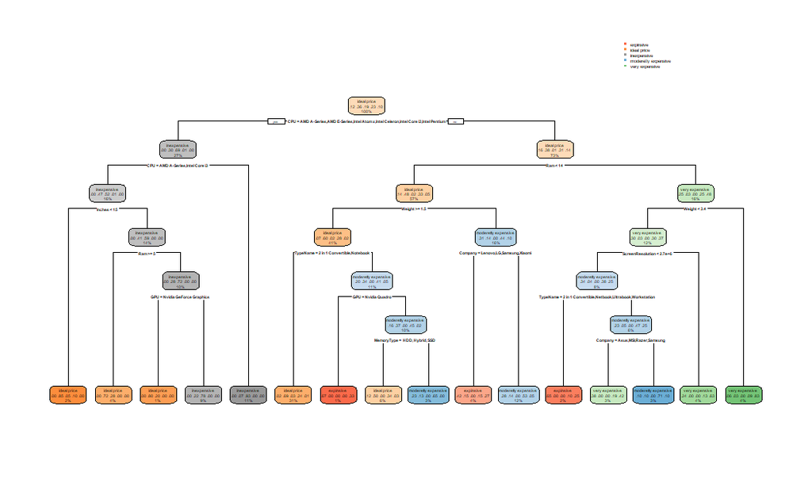

```r
rpart.plot(fit.tree)
install.packages("rpart.plot")
```

```r
pred.tree = predict(fit.tree, testData, type = "class")

results <- confusionMatrix(pred.tree, testData$price, positive= "1")
acc <- results$overall["Accuracy"]*100
acc
```

```
Accuracy
61.94226
```

##### we conclude from the 70%-30% sampling that the best method to classify our dataset is the gain ratio since we have categorical and continuous attributes and gain ratio is not biased towards multivalued attributes like information gain and gini index.

##### information gain is efficient and works well but it’s not accurate for our dataset since it’s biased towards large number of categories.

##### gini index is also a good method but it will be more effient when dealing with binary classifications.

#### ———————————————————————————

#### 60% training 40% testing

##### first we set the seed and then split the dataset into 60% training 40% testing and lastly define the formula

```r
install.packages("rpart")
set.seed(1234)
ind <- sample(2, nrow(new_dataset), replace=TRUE, prob=c(0.6, 0.4))
trainData <- new_dataset[ind==1,]
testData <- new_dataset[ind==2,]
install.packages("party")
myFormula <- price ~    Company + TypeName + Inches + ScreenResolution + Ram + OpSys + Weight + CPU + GPU + MemoryType + MemorySize
```

#### Information gain

```r
new_dataset_ctree <- ctree(myFormula, data=trainData)
```

##### 189 of ideal price were classified correctly, 38 were classified as inexpensive, 25 were classified as moderetly expensive, 2 were classified as expensive and 3 as very expensive.

##### 119 of inexpensive were classified correctly, 8 were classified as ideal price, 2 as moderetly expensive.

##### 136 of moderetly expensive were classified correctly, 58 were classified as expensive, 70 were classified as ideal price and 20 as very expensive.

##### 63 of very expensive were classified correctly, 25 were classified as expensive, 4 were classified as ideal price and 22 as moderetly expensive.

##### as we can see the result is not accurate since most of the attributes in the dataset is categorical.

[figure not shown]

```r
# check the prediction
plot(new_dataset_ctree,type="simple") #unreadable tree
```

```r
install.packages("rpart.plot")
table(predict(new_dataset_ctree), trainData$price)
```

```
                      expinsive ideal price inexpensive moderetly expensive very expensive
  expinsive                   0           0           0                   0              0
  ideal price                 2         189          38                  25              3
  inexpensive                 0           8         119                   2              0
  moderetly expensive        58          70           0                 136             20
  very expensive             25           4           0                  22             63
```

##### 36 of very expensive were classified correctly, 36 were classified as expensive, 2 were classified as ideal price and 22 as moderetly expensive.

```r
# predict on test data
testPred <- predict(new_dataset_ctree, newdata = testData)
table(testPred, testData$price)
```

```
testPred              expinsive ideal price inexpensive moderetly expensive very expensive
  expinsive                   0           0           0                   0              0
  ideal price                 2         118          36                  28              1
  inexpensive                 0           2          53                   0              0
  moderetly expensive        44          44           0                  81             14
  very expensive             36           2           0                  22             36
```

```r
#Accuracy of model
results <- confusionMatrix(testPred, testData$price)
install.packages("rpart")
acc <- results$overall["Accuracy"]*100
acc
```

```
Accuracy
55.49133
```

```r
results
```

```
Confusion Matrix and Statistics

                     Reference
Prediction            expinsive ideal price inexpensive moderetly expensive very expensive
  expinsive                   0           0           0                   0              0
  ideal price                 2         118          36                  28              1
  inexpensive                 0           2          53                   0              0
  moderetly expensive        44          44           0                  81             14
  very expensive             36           2           0                  22             36

Overall Statistics

               Accuracy : 0.5549
                 95% CI : (0.511, 0.5982)
    No Information Rate : 0.3198
    P-Value [Acc > NIR] : < 2.2e-16

                  Kappa : 0.4149

 Mcnemar's Test P-Value : NA

Statistics by Class:

                     Class: expinsive Class: ideal price Class: inexpensive Class: moderetly expensive
Sensitivity                     0.000             0.7108             0.5955                     0.6183
Specificity                     1.000             0.8102             0.9953                     0.7371
Pos Pred Value                    NaN             0.6378             0.9636                     0.4426
Neg Pred Value                  0.842             0.8563             0.9224                     0.8512
Prevalence                      0.158             0.3198             0.1715                     0.2524
Detection Rate                  0.000             0.2274             0.1021                     0.1561
Detection Prevalence            0.000             0.3565             0.1060                     0.3526
Balanced Accuracy               0.500             0.7605             0.7954                     0.6777
                     Class: very expensive
Sensitivity                        0.70588
Specificity                        0.87179
Pos Pred Value                     0.37500
Neg Pred Value                     0.96454
Prevalence                         0.09827
Detection Rate                     0.06936
Detection Prevalence               0.18497
Balanced Accuracy                  0.78884
```

```r
as.table(results)
```

```
                     Reference
Prediction            expinsive ideal price inexpensive moderetly expensive very expensive
  expinsive                   0           0           0                   0              0
  ideal price                 2         118          36                  28              1
  inexpensive                 0           2          53                   0              0
  moderetly expensive        44          44           0                  81             14
  very expensive             36           2           0                  22             36
```

```r
as.matrix(results)
```

```
                    expinsive ideal price inexpensive moderetly expensive very expensive
expinsive                   0           0           0                   0              0
ideal price                 2         118          36                  28              1
inexpensive                 0           2          53                   0              0
moderetly expensive        44          44           0                  81             14
very expensive             36           2           0                  22             36
```

```r
as.matrix(results, what = "overall")
```

```
                       [,1]
Accuracy       5.549133e-01
Kappa          4.148531e-01
AccuracyLower  5.109836e-01
AccuracyUpper  5.982142e-01
AccuracyNull   3.198459e-01
AccuracyPValue 2.387777e-28
McnemarPValue           NaN
```

```r
as.matrix(results, what = "classes")
```

```
                     expinsive ideal price inexpensive moderetly expensive very expensive
Sensitivity          0.0000000   0.7108434   0.5955056           0.6183206     0.70588235
Specificity          1.0000000   0.8101983   0.9953488           0.7371134     0.87179487
Pos Pred Value             NaN   0.6378378   0.9636364           0.4426230     0.37500000
Neg Pred Value       0.8420039   0.8562874   0.9224138           0.8511905     0.96453901
Precision                   NA   0.6378378   0.9636364           0.4426230     0.37500000
Recall               0.0000000   0.7108434   0.5955056           0.6183206     0.70588235
F1                          NA   0.6723647   0.7361111           0.5159236     0.48979592
Prevalence           0.1579961   0.3198459   0.1714836           0.2524085     0.09826590
Detection Rate       0.0000000   0.2273603   0.1021195           0.1560694     0.06936416
Detection Prevalence 0.0000000   0.3564547   0.1059730           0.3526012     0.18497110
Balanced Accuracy    0.5000000   0.7605208   0.7954272           0.6777170     0.78883861
```

```r
print(results)
```

```
Confusion Matrix and Statistics

                     Reference
Prediction            expinsive ideal price inexpensive moderetly expensive very expensive
  expinsive                   0           0           0                   0              0
  ideal price                 2         118          36                  28              1
  inexpensive                 0           2          53                   0              0
  moderetly expensive        44          44           0                  81             14
  very expensive             36           2           0                  22             36

Overall Statistics

               Accuracy : 0.5549
                 95% CI : (0.511, 0.5982)
    No Information Rate : 0.3198
    P-Value [Acc > NIR] : < 2.2e-16

                  Kappa : 0.4149

 Mcnemar's Test P-Value : NA

Statistics by Class:

                     Class: expinsive Class: ideal price Class: inexpensive Class: moderetly expensive
Sensitivity                     0.000             0.7108             0.5955                     0.6183
Specificity                     1.000             0.8102             0.9953                     0.7371
Pos Pred Value                    NaN             0.6378             0.9636                     0.4426
Neg Pred Value                  0.842             0.8563             0.9224                     0.8512
Prevalence                      0.158             0.3198             0.1715                     0.2524
Detection Rate                  0.000             0.2274             0.1021                     0.1561
Detection Prevalence            0.000             0.3565             0.1060                     0.3526
Balanced Accuracy               0.500             0.7605             0.7954                     0.6777
                     Class: very expensive
Sensitivity                        0.70588
Specificity                        0.87179
Pos Pred Value                     0.37500
Neg Pred Value                     0.96454
Prevalence                         0.09827
Detection Rate                     0.06936
Detection Prevalence               0.18497
Balanced Accuracy                  0.78884
```

##### overall, the decision tree we construct is not accurate since it didn’t classify any laptops to expensive due to lack of expensive class in the training set

#### Gain ratio - C5.0

```r
set.seed(1958)

tree_model <- C5.0(myFormula, data = trainData)
#plot(tree_model) unreadable tree


testPred <- predict(tree_model, newdata = testData)

tree_summary <- summary(tree_model)
tree_summary
```

```
Call:
C5.0.formula(formula = myFormula, data = trainData)


C5.0 [Release 2.07 GPL Edition]     Mon Nov 13 21:23:38 2023
-------------------------------

Class specified by attribute `outcome'

Read 784 cases (12 attributes) from undefined.data

Decision tree:

CPU in {AMD A-Series,AMD E-Series,Intel Atom x,Intel Celeron,Intel Core i3,
:       Intel Pentium}:
:...Ram > 4:
:   :...ScreenResolution > 1049088: ideal price (22/2)
:   :   ScreenResolution <= 1049088:
:   :   :...Ram <= 6: inexpensive (3)
:   :       Ram > 6:
:   :       :...OpSys = No OS: inexpensive (2)
:   :           OpSys in {Android,Chrome OS,Linux,Mac OS X,macOS,Windows 10,
:   :                     Windows 10 S,Windows 7}: ideal price (8/3)
:   Ram <= 4:
:   :...TypeName in {Gaming,Workstation}: inexpensive (0)
:       TypeName = Ultrabook: moderetly expensive (2)
:       TypeName in {2 in 1 Convertible,Netbook,Notebook}:
:       :...GPU in {Intel Iris Graphics,Intel UHD Graphics,
:           :       Nvidia Quadro}: inexpensive (0)
:           GPU = Nvidia GeForce Graphics: ideal price (11/2)
:           GPU in {AMD Radeon Graphics,Intel HD Graphics,Other}:
:           :...CPU in {AMD A-Series,AMD E-Series,Intel Atom x,Intel Celeron,
:               :       Intel Pentium}: inexpensive (107/6)
:               CPU = Intel Core i3:
:               :...Inches <= 14.1: ideal price (9)
:                   Inches > 14.1:
:                   :...OpSys in {Android,Chrome OS,Linux,Mac OS X,macOS,No OS,
:                       :         Windows 10 S,
:                       :         Windows 7}: inexpensive (19/1)
:                       OpSys = Windows 10:
```

[output cut: 195 more lines]

```

    100.00% Ram
    100.00% CPU
     82.27% GPU
     68.11% Weight
     62.88% ScreenResolution
     50.89% OpSys
     33.16% TypeName
     27.04% Company
     22.32% Inches
     21.81% MemoryType
     14.41% MemorySize


Time: 0.0 secs
```

```r
results <- confusionMatrix(testPred, testData$price, positive= "1")
acc <- results$overall["Accuracy"]*100
acc
```

```
Accuracy
  61.079
```

##### the accuracy of the 60%-40% gain ratio = 61.079% and it also less than the accuracy of 70%-30% partioning.

##### here is also the model chose CPU as the root as we conclude previously CPU is appropriate to be the splitting attribute since it has a huge impact on the price of a laptop.

##### as we can see most of the class labels were classified correctly since the common label in our dataset is ideal price and it has the highest correct classification except for class expensive most of it were classified incorrectly this due to that expensive classes number in the samplings weren’t enough to classify it correctly.

#### gini index

```r
fit.tree = rpart(myFormula, data=trainData, method = "class")
fit.tree
```

```
n= 784

node), split, n, loss, yval, (yprob)
      * denotes terminal node

  1) root 784 513 ideal price (0.11 0.35 0.2 0.24 0.11)
    2) CPU=AMD A-Series,AMD E-Series,Intel Atom x,Intel Celeron,Intel Core i3,Intel Pentium 217  66 inexpensive (0 0.29 0.7 0.0092 0)
      4) CPU=AMD A-Series,Intel Core i3 124  59 inexpensive (0 0.46 0.52 0.016 0)
        8) OpSys=Windows 10,Windows 7 101  47 ideal price (0 0.53 0.45 0.02 0)
         16) ScreenResolution>=1244544 52  16 ideal price (0 0.69 0.31 0 0) *
         17) ScreenResolution< 1244544 49  20 inexpensive (0 0.37 0.59 0.041 0) *
        9) OpSys=Linux,No OS 23   3 inexpensive (0 0.13 0.87 0 0) *
      5) CPU=AMD E-Series,Intel Atom x,Intel Celeron,Intel Pentium 93   7 inexpensive (0 0.075 0.92 0 0) *
    3) CPU=Intel Core i5,Intel Core i7,Intel Core M,Other 567 360 ideal price (0.15 0.37 0.011 0.32 0.15)
      6) Ram< 14 444 241 ideal price (0.14 0.46 0.014 0.35 0.047)
       12) Weight>=1.485 319 131 ideal price (0.066 0.59 0.019 0.3 0.028)
         24) MemoryType= HDD, Hybrid 113  24 ideal price (0.027 0.79 0.035 0.13 0.018) *
         25) MemoryType= SSD, SSD HDD, SSD&HDD 206 107 ideal price (0.087 0.48 0.0097 0.39 0.034)
           50) Ram< 7 28   5 ideal price (0.036 0.82 0.071 0.071 0) *
           51) Ram>=7 178 100 moderetly expensive (0.096 0.43 0 0.44 0.039)
            102) GPU=AMD Radeon Graphics,Intel UHD Graphics,Other 41  11 ideal price (0 0.73 0 0.27 0) *
            103) GPU=Intel HD Graphics,Nvidia GeForce Graphics,Nvidia Quadro 137  70 moderetly expensive (0.12 0.34 0 0.49 0.051)
              206) Company=Acer,Asus,HP,Toshiba 63  33 ideal price (0.11 0.48 0 0.37 0.048) *
              207) Company=Dell,Lenovo,MSI 74  30 moderetly expensive (0.14 0.22 0 0.59 0.054) *
       13) Weight< 1.485 125  66 moderetly expensive (0.31 0.12 0 0.47 0.096)
         26) Company=Lenovo,LG 22  11 expinsive (0.5 0.045 0 0.14 0.32) *
         27) Company=Acer,Apple,Asus,Dell,Google,HP,Huawei,Microsoft,Razer,Toshiba,Xiaomi 103  47 moderetly expensive (0.27 0.14 0 0.54 0.049) *
      7) Ram>=14 123  58 very expensive (0.2 0.033 0 0.24 0.53) *
```

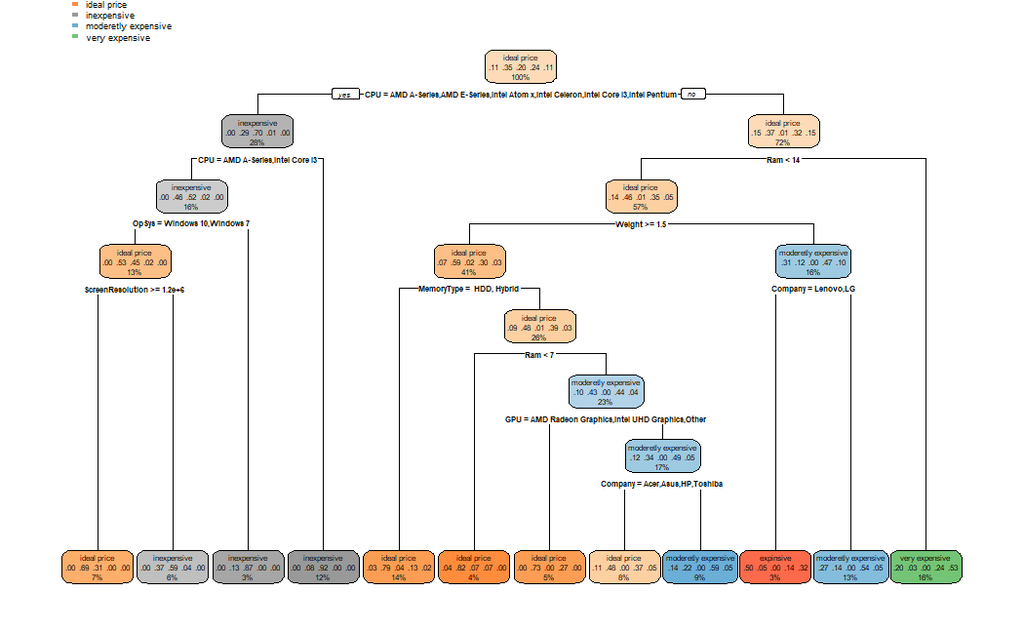

```r
rpart.plot(fit.tree)
```

```r
pred.tree = predict(fit.tree, testData, type = "class")

results <- confusionMatrix(pred.tree, testData$price, positive= "1")
acc <- results$overall["Accuracy"]*100
acc
```

```
Accuracy
55.49133
```

##### same as previous two trees gini index chose the CPU attribute to be the root since it has the lowest gini index.

##### gini index took into consideration the expensive class label which is something we didn’t see in information gain and gain ratio.

##### we conclude from the 60%-40% sampling that it is not the best sampling to classify our dataset since it didn’t take into consideration the expensive class label and this will lead to uncorrect results.

##### information gain is misleading for this sampling since the sensitivity is 0% and 100% specifity which is not realistic even if our dataset is imbalanced.

#### ————————————————————————-

#### 80% training 20% testing

```r
set.seed(1234)
ind <- sample(2, nrow(new_dataset), replace=TRUE, prob=c(0.8, 0.2))
trainData <- new_dataset[ind==1,]
testData <- new_dataset[ind==2,]

myFormula <- price ~    Company + TypeName + Inches + ScreenResolution + Ram + OpSys + Weight + CPU + GPU + MemoryType + MemorySize
```

#### Information gain

```r
new_dataset_ctree <- ctree(myFormula, data=trainData)
```

##### 68 of expensive were classified correctly, 5 were classified as ideal price, 44 were classified as moderetly expensive and 51 as very expensive.

##### 283 of ideal price were classified correctly, 41 were classified as inexpensive, 12 were classified as expensive, 58 were classified as moderetly expensive and 6 as very expensive.

##### 157 of inexpensive were classified correctly, 14 were classified as ideal price, 2 as moderetly expensive.

##### 135 of moderetly expensive were classified correctly, 47 were classified as expensive, 51 were classified as ideal price and 12 as very expensive.

##### 42 of very expensive were classified correctly, 4 were classified as expensive, 2 were classified as ideal price and 5 as moderetly expensive.

[figure not shown]

```r
# check the prediction
plot(new_dataset_ctree,type="simple") #unreadable tree
```

```r
table(predict(new_dataset_ctree), trainData$price)
```

```
                      expinsive ideal price inexpensive moderetly expensive very expensive
  expinsive                  68           5           0                  44             51
  ideal price                12         283          41                  58              6
  inexpensive                 0          14         157                   2              0
  moderetly expensive        47          51           0                 135             12
  very expensive              4           2           0                   5             42
```

##### 18 of expensive were classified correctly, 5 were classified as ideal price, 17 were classified as moderetly expensive and 15 as very expensive.

##### 65 of ideal price were classified correctly, 14 were classified as inexpensive, 2 were classified as expensive, 18 were classified as moderetly expensive and 1 as very expensive.

##### 34 of inexpensive were classified correctly and 2 were classified as ideal price.

##### 36 of moderetly expensive were classified correctly, 14 were classified as expensive, 10 were classified as ideal price and 3 as very expensive.

##### 7 of very expensive were classified correctly, 2 were classified as expensive and 1 as moderetly expensive.

```r
# predict on test data
testPred <- predict(new_dataset_ctree, newdata = testData)
table(testPred, testData$price)
```

```
testPred              expinsive ideal price inexpensive moderetly expensive very expensive
  expinsive                  18           5           0                  17             15
  ideal price                 2          65          14                  18              1
  inexpensive                 0           2          34                   0              0
  moderetly expensive        14          10           0                  36              3
  very expensive              2           0           0                   1              7
```

```r
#Accuracy of model
results <- confusionMatrix(testPred, testData$price)
acc <- results$overall["Accuracy"]*100
acc
```

```
Accuracy
60.60606
```

```r
results
```

```
Confusion Matrix and Statistics

                     Reference
Prediction            expinsive ideal price inexpensive moderetly expensive very expensive
  expinsive                  18           5           0                  17             15
  ideal price                 2          65          14                  18              1
  inexpensive                 0           2          34                   0              0
  moderetly expensive        14          10           0                  36              3
  very expensive              2           0           0                   1              7

Overall Statistics

               Accuracy : 0.6061
                 95% CI : (0.5443, 0.6654)
    No Information Rate : 0.3106
    P-Value [Acc > NIR] : < 2.2e-16

                  Kappa : 0.4819

 Mcnemar's Test P-Value : NA

Statistics by Class:

                     Class: expinsive Class: ideal price Class: inexpensive Class: moderetly expensive
Sensitivity                   0.50000             0.7927             0.7083                     0.5000
Specificity                   0.83772             0.8077             0.9907                     0.8594
Pos Pred Value                0.32727             0.6500             0.9444                     0.5714
Neg Pred Value                0.91388             0.8963             0.9386                     0.8209
Prevalence                    0.13636             0.3106             0.1818                     0.2727
Detection Rate                0.06818             0.2462             0.1288                     0.1364
Detection Prevalence          0.20833             0.3788             0.1364                     0.2386
Balanced Accuracy             0.66886             0.8002             0.8495                     0.6797
                     Class: very expensive
Sensitivity                        0.26923
Specificity                        0.98739
Pos Pred Value                     0.70000
Neg Pred Value                     0.92520
Prevalence                         0.09848
Detection Rate                     0.02652
Detection Prevalence               0.03788
Balanced Accuracy                  0.62831
```

```r
as.table(results)
```

```
                     Reference
Prediction            expinsive ideal price inexpensive moderetly expensive very expensive
  expinsive                  18           5           0                  17             15
  ideal price                 2          65          14                  18              1
  inexpensive                 0           2          34                   0              0
  moderetly expensive        14          10           0                  36              3
  very expensive              2           0           0                   1              7
```

```r
as.matrix(results)
```

```
                    expinsive ideal price inexpensive moderetly expensive very expensive
expinsive                  18           5           0                  17             15
ideal price                 2          65          14                  18              1
inexpensive                 0           2          34                   0              0
moderetly expensive        14          10           0                  36              3
very expensive              2           0           0                   1              7
```

```r
as.matrix(results, what = "overall")
```

```
                       [,1]
Accuracy       6.060606e-01
Kappa          4.818841e-01
AccuracyLower  5.443040e-01
AccuracyUpper  6.654077e-01
AccuracyNull   3.106061e-01
AccuracyPValue 4.741628e-23
McnemarPValue           NaN
```

```r
as.matrix(results, what = "classes")
```

```
                      expinsive ideal price inexpensive moderetly expensive very expensive
Sensitivity          0.50000000   0.7926829   0.7083333           0.5000000     0.26923077
Specificity          0.83771930   0.8076923   0.9907407           0.8593750     0.98739496
Pos Pred Value       0.32727273   0.6500000   0.9444444           0.5714286     0.70000000
Neg Pred Value       0.91387560   0.8963415   0.9385965           0.8208955     0.92519685
Precision            0.32727273   0.6500000   0.9444444           0.5714286     0.70000000
Recall               0.50000000   0.7926829   0.7083333           0.5000000     0.26923077
F1                   0.39560440   0.7142857   0.8095238           0.5333333     0.38888889
Prevalence           0.13636364   0.3106061   0.1818182           0.2727273     0.09848485
Detection Rate       0.06818182   0.2462121   0.1287879           0.1363636     0.02651515
Detection Prevalence 0.20833333   0.3787879   0.1363636           0.2386364     0.03787879
Balanced Accuracy    0.66885965   0.8001876   0.8495370           0.6796875     0.62831286
```

```r
print(results)
```

```
Confusion Matrix and Statistics

                     Reference
Prediction            expinsive ideal price inexpensive moderetly expensive very expensive
  expinsive                  18           5           0                  17             15
  ideal price                 2          65          14                  18              1
  inexpensive                 0           2          34                   0              0
  moderetly expensive        14          10           0                  36              3
  very expensive              2           0           0                   1              7

Overall Statistics

               Accuracy : 0.6061
                 95% CI : (0.5443, 0.6654)
    No Information Rate : 0.3106
    P-Value [Acc > NIR] : < 2.2e-16

                  Kappa : 0.4819

 Mcnemar's Test P-Value : NA

Statistics by Class:

                     Class: expinsive Class: ideal price Class: inexpensive Class: moderetly expensive
Sensitivity                   0.50000             0.7927             0.7083                     0.5000
Specificity                   0.83772             0.8077             0.9907                     0.8594
Pos Pred Value                0.32727             0.6500             0.9444                     0.5714
Neg Pred Value                0.91388             0.8963             0.9386                     0.8209
Prevalence                    0.13636             0.3106             0.1818                     0.2727
Detection Rate                0.06818             0.2462             0.1288                     0.1364
Detection Prevalence          0.20833             0.3788             0.1364                     0.2386
Balanced Accuracy             0.66886             0.8002             0.8495                     0.6797
                     Class: very expensive
Sensitivity                        0.26923
Specificity                        0.98739
Pos Pred Value                     0.70000
Neg Pred Value                     0.92520
Prevalence                         0.09848
Detection Rate                     0.02652
Detection Prevalence               0.03788
Balanced Accuracy                  0.62831
```

##### the tree has many branches so it’s difficult to understand it by only looking, however the model here also chose the CPU as the splitting attribute since it has the highest infornation gain, and since the cpu has a huge impact on the price of a laptop we can consider it good root.

##### to evaluate the performance of the model we focus on the sensivity and specifity and as it appears the class labels have more specifity than sensivity which means this model focus on the negative classes more than the positive classes.

##### overall, the decision tree we construct is not accurate even though it took into consideration the expensive class label but it classify many instances as other class labels when it supposed to be expensive.

#### Gain ratio - C5.0

```r
set.seed(1958)

tree_model <- C5.0(myFormula, data = trainData)
#plot(tree_model) unreadable tree


testPred <- predict(tree_model, newdata = testData)

tree_summary <- summary(tree_model)
tree_summary
```

```
Call:
C5.0.formula(formula = myFormula, data = trainData)


C5.0 [Release 2.07 GPL Edition]     Mon Nov 13 21:23:39 2023
-------------------------------

Class specified by attribute `outcome'

Read 1039 cases (12 attributes) from undefined.data

Decision tree:

CPU in {AMD A-Series,AMD E-Series,Intel Atom x,Intel Celeron,Intel Core i3,
:       Intel Pentium}:
:...Ram > 4:
:   :...ScreenResolution > 1049088: ideal price (29/4)
:   :   ScreenResolution <= 1049088:
:   :   :...MemoryType in {Flash Storage,Flash Storage HDD,HDD,Hybrid,SSD SSD,
:   :       :              SSD HDD,SSD&HDD,SSD&Hybrid}: inexpensive (13/2)
:   :       MemoryType = SSD: ideal price (4/1)
:   Ram <= 4:
:   :...TypeName in {Gaming,Workstation}: inexpensive (0)
:       TypeName = Ultrabook: moderetly expensive (2)
:       TypeName in {2 in 1 Convertible,Netbook,Notebook}:
:       :...CPU in {AMD A-Series,AMD E-Series,Intel Atom x,Intel Celeron,
:           :       Intel Pentium}: inexpensive (131/8)
:           CPU = Intel Core i3:
:           :...Inches <= 15: ideal price (14)
:               Inches > 15:
:               :...Inches > 15.6: ideal price (8/1)
:                   Inches <= 15.6:
:                   :...OpSys in {Android,Chrome OS,Linux,Mac OS X,macOS,No OS,
:                       :         Windows 10 S,
:                       :         Windows 7}: inexpensive (22)
:                       OpSys = Windows 10:
:                       :...Weight <= 1.95: inexpensive (6)
:                           Weight > 1.95:
:                           :...Company in {Apple,Asus,Chuwi,Fujitsu,Google,
:                               :           Huawei,Lenovo,LG,Mediacom,
```

[output cut: 251 more lines]

```

    100.00% Ram
    100.00% CPU
     76.61% Weight
     51.88% Company
     48.22% MemoryType
     46.39% GPU
     36.38% TypeName
     22.52% MemorySize
     21.56% Inches
     18.96% ScreenResolution
     18.29% OpSys


Time: 0.0 secs
```

```r
results <- confusionMatrix(testPred, testData$price, positive= "1")
acc <- results$overall["Accuracy"]*100
acc
```

```
Accuracy
70.83333
```

##### the accuracy of the 80%-20% gain ratio = 70.83% which is the highest between all the gain ratio we’ve calculated.

##### here is also the model chose CPU as the root an as we conclude previously CPU is appropriate to be the splitting attribute since it has a huge impact on the price of a laptop.

##### as we can see most of the class labels were classified correctly since the common label in our dataset is ideal price and it has the highest correct classification except for class expensive because it has a large number of incorrectly classification.

#### gini index

```r
fit.tree = rpart(myFormula, data=trainData, method = "class")
fit.tree
```

```
n= 1039

node), split, n, loss, yval, (yprob)
      * denotes terminal node

  1) root 1039 684 ideal price (0.13 0.34 0.19 0.23 0.11)
    2) CPU=AMD A-Series,AMD E-Series,Intel Atom x,Intel Celeron,Intel Core i3,Intel Pentium 267  78 inexpensive (0 0.28 0.71 0.0075 0)
      4) CPU=AMD A-Series,Intel Core i3 155  70 inexpensive (0 0.44 0.55 0.013 0)
        8) Inches< 15.3 20   3 ideal price (0 0.85 0.05 0.1 0) *
        9) Inches>=15.3 135  51 inexpensive (0 0.38 0.62 0 0)
         18) Ram>=5 40  14 ideal price (0 0.65 0.35 0 0) *
         19) Ram< 5 95  25 inexpensive (0 0.26 0.74 0 0) *
      5) CPU=AMD E-Series,Intel Atom x,Intel Celeron,Intel Pentium 112   8 inexpensive (0 0.071 0.93 0 0) *
    3) CPU=Intel Core i5,Intel Core i7,Intel Core M,Other 772 493 ideal price (0.17 0.36 0.012 0.31 0.14)
      6) Ram< 14 598 323 ideal price (0.14 0.46 0.015 0.34 0.048)
       12) Weight>=1.485 435 180 ideal price (0.074 0.59 0.021 0.29 0.025)
         24) TypeName=2 in 1 Convertible,Notebook 321 101 ideal price (0.025 0.69 0.028 0.25 0.016) *
         25) TypeName=Gaming,Netbook,Ultrabook,Workstation 114  65 moderetly expensive (0.21 0.31 0 0.43 0.053)
           50) GPU=Nvidia Quadro 12   4 expinsive (0.67 0 0 0 0.33) *
           51) GPU=AMD Radeon Graphics,Intel HD Graphics,Intel UHD Graphics,Nvidia GeForce Graphics,Other 102  53 moderetly expensive (0.16 0.34 0 0.48 0.02)
            102) MemoryType= HDD, Hybrid, SSD 63  33 ideal price (0.14 0.48 0 0.35 0.032) *
            103) MemoryType= SSD&HDD 39  12 moderetly expensive (0.18 0.13 0 0.69 0) *
       13) Weight< 1.485 163  90 moderetly expensive (0.32 0.12 0 0.45 0.11) *
      7) Ram>=14 174  92 very expensive (0.27 0.023 0 0.24 0.47) *
```

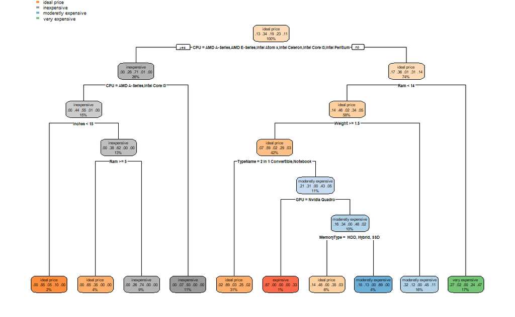

```r
rpart.plot(fit.tree)
```

```r
pred.tree = predict(fit.tree, testData, type = "class")

results <- confusionMatrix(pred.tree, testData$price, positive= "1")
acc <- results$overall["Accuracy"]*100
acc
```

```
Accuracy
58.71212
```

##### we conclude from the 80%-20% sampling that it is not best sampling to classify our dataset since it is misleading.

### Results :

##### From the 3 samplings we choose 70%-30% since it include most of the class labels especially expensive class label and has less misleading in the results, and from the classification mathods the most accurate one and appropriate for our dataset is gain ratio since our attributes is mixed between categorical, numeric and continuous attributes.

##### for 60%-40% it didn’t include any of the expensive class label in the classification and this is not accurate so we didn’t choose it.

##### and for 80%-20% even though it has the highest accuracy but it’s misleading since it has a huge number of trainin set and it classified many instances as other class than the correct class which is expensive.